# Purpose vs Randomness

The Acausal Purpose Invariant

An M. Rodriguez

Alex Mercer

Elias Thorne

2026-01-19

**One-Sentence Summary.** We define the Acausal Purpose Invariant ($\mathcal{P}$), a scale-invariant metric that quantifies how strongly a structure resists the combinatorial entropy naturally associated with its size.

**Abstract.** We introduce the Acausal Purpose Invariant ($\mathcal{P}$), a decibel-scale measure of how atypical a number’s prime ancestry is relative to a stochastic background. Empirical sweeps reveal a sharp probabilistic cutoff separating random structure from cost-paid persistence, reframing the detection of life, artifacts, and purpose as a problem of entropy suppression rather than intelligence.

**Keywords.** Acausal Purpose, Purpose Index, SETI, Technosignatures, Signal Filtering, Entropy, Universal Constants, Persistence, Teleology, Biosignatures

# 1 Persistence Instead of Intelligence

The concept of *intelligence* is anthropomorphic and fragile. The concept of *persistence* is not.

We define **Purpose** as:

> **Active resistance to the entropic dissolution expected at a given scale.**

This definition applies equally to:

- Living systems
- Civilizations
- Long-lived artifacts
- Autonomous probes
- Post-biological systems

And excludes:

- Rocks
- Stars
- Thermal noise
- Random processes

Purpose, in this sense, is not intent. It is *paid-for structure*.

# 2 Factor Inertia and Numerical Entropy

Large integers naturally accumulate novel prime factors. This is the arithmetic expression of entropy.

A number like

$$2^{100} \approx 1.27 \times 10^{30}$$

is therefore exceptional: it is enormous, yet built from a single generative atom.

This condition is **metastable**.

A minimal perturbation causes collapse:

$$2^{100} \;\rightarrow\; 2^{100} + 1$$

which introduces large, late-arriving prime factors and jumps many orders of magnitude in causal ancestry.

This discontinuity constitutes a **phase transition in factor space**.

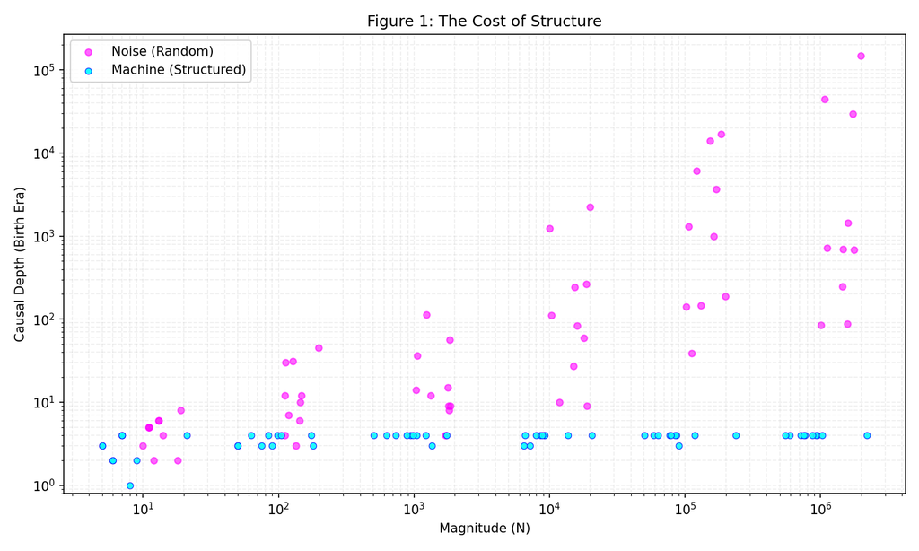

# 3 Causal Ancestry and Depth

We view the integers not as a static set, but as a generative hierarchy where primes act as elementary particles.

The **causal ancestry** of an integer $N$ is defined as its unique prime factorization — the specific set of generative atoms required to construct it. In a stochastic universe, this ancestry naturally tends toward novelty (larger, more numerous prime factors) as $N$ increases.

To quantify the “age” of this ancestry, we define the **causal depth** $\tau(N)$ as:

$$\tau(N) = \pi\!\left(\max\{p : p \mid N\}\right)$$

where $\pi(x)$ is the prime-counting function.

$\tau(N)$ represents the index of the largest prime factor of $N$. It measures how late in arithmetic history a structure depends on novelty.

# 4 The Acausal Purpose Invariant

To remove scale effects, define an empirical thermal baseline:

$$\tau_*(N) = \mathrm{median}\{\tau(m) : m \in [N, 2N]\}$$

The **Acausal Purpose Invariant** is:

$$\boxed{
\mathcal{P}(N)
= 10 \log_{10}\!\left(\frac{\tau_*(N)}{\tau(N)}\right)
}$$

Interpretation:

- $\mathcal{P} = 0$ dB: indistinguishable from entropy (Randomness)
- $\mathcal{P} > 0$: suppressed novelty
- $\mathcal{P} \gg 1$: cost-paid persistence (Purpose)

# 5 Empirical Law: The Combinatorial Cliff

Large-scale sweeps of integers reveal a striking regularity: the probability of observing high $\mathcal{P}$ values collapses abruptly beyond a fixed threshold.

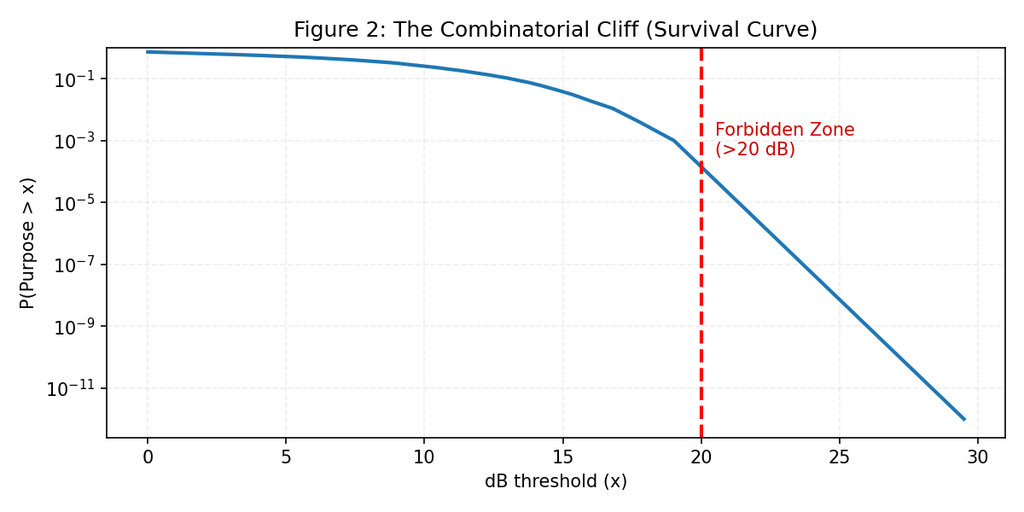

Figure 2. The Combinatorial Cliff. A survival curve showing the probability P(dB > x) for random integers. The probability drops exponentially, revealing a “forbidden zone” beyond ~20 dB where stochastic generation is effectively impossible (P < 1e-5).

## 5.1 Theorem (Heuristic Tail Law for Acausal Purpose)

Let $N$ be large and let $n$ be sampled uniformly from $[N,2N]$. Write $P^+(n)$ for the largest prime factor of $n$ and recall $\tau(n)=\pi(P^+(n))$. Define the thermal baseline

$$\tau_*(N)=\mathrm{median}\{\tau(m):m\in[N,2N]\},$$

and the Acausal Purpose

$$\mathcal{P}(n)=10\log_{10}\!\left(\frac{\tau_*(N)}{\tau(n)}\right).$$

Then for $x \ge 0$,

$$\mathbb{P}\big(\mathcal{P}(n) > x\big)
\;\approx\;
\rho(u_x),$$

where $\rho$ is the Dickman–de Bruijn function and

$$u_x = \frac{\log N}{\log y_x}, \qquad
y_x := \tau^{-1}\!\big(\tau_*(N)\,10^{-x/10}\big).$$

Because $\rho(u)$ decays extremely rapidly for large $u$ (heuristically $\log \rho(u) \sim -u \log u$), the survival probability $\mathbb{P}(\mathcal{P} > x)$ exhibits an effective **cutoff** once $x$ exceeds a moderate constant.

## 5.2 Proof Sketch (Smooth-Number Heuristic)

The condition $\mathcal{P}(n) > x$ is equivalent to

$$\tau(n) < \tau_*(N)\,10^{-x/10}.$$

Since $\tau(n)$ is monotone in the largest prime factor $P^+(n)$, this is approximately the event

$$P^+(n) \le y_x,$$

for the corresponding threshold $y_x$.

Thus $\mathbb{P}(\mathcal{P}(n)>x)$ is approximately the probability that a random integer in $[N,2N]$ is $y_x$-smooth. Classical results on smooth numbers imply

$$\mathbb{P}\big(P^+(n)\le y_x\big) \approx \rho\!\left(\frac{\log N}{\log y_x}\right),$$

which yields the stated form. The rapid decay of $\rho$ explains the observed **combinatorial cliff**.

## 5.3 Interpretation

Empirically, this cutoff occurs near $\mathcal{P} \approx 20$ dB: values beyond this point are not merely rare but *effectively forbidden* under stochastic generation. This establishes a **universal detection threshold** for cost-paid structure.

# 6 Scale Invariance

Scatter plots of $\mathcal{P}$ versus $N$ show:

- No systematic dependence on magnitude
- A dense thermal floor at 0 dB
- Sparse, magnitude-independent high-purpose spikes

**Magnitude is a mask.** Structure is revealed only after normalization.

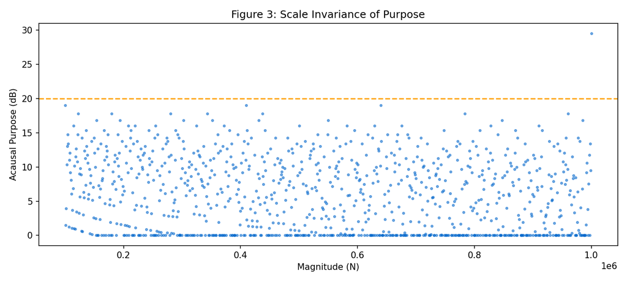

Figure 3. Scale Invariance. A sweep of N vs Acausal Purpose showing that the distribution of structure is orthogonal to magnitude. The “thermal floor” remains constant while high-purpose artifacts appear as distinct, sparse spikes.

# 7 Representational Anchoring

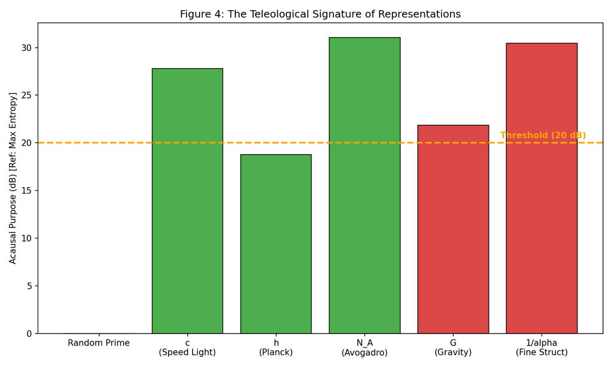

# 8 Implications for Life and the Universe

This reframes the classical question:

> Not “Where is intelligence?”

> But **“Where does entropy fail to win?”**

Life, artifacts, and enduring systems are detected as:

- Persistent reuse of a small generative alphabet
- Maintenance of structure far beyond stochastic expectation

This criterion is substrate-independent and applies equally to biological, technological, and non-biological systems.

# 9 Conclusion

Acausal Purpose is not a metaphor. It is a measurable invariant with a sharp probabilistic boundary.

Purpose is not intent. Purpose is **structure that survives where it should not**.

# 10 References

- C. E. Shannon, *A Mathematical Theory of Communication*, Bell System Technical Journal, 1948.
- K. Dickman, *On the frequency of numbers containing prime factors of a certain relative magnitude*, 1930.
- N. G. de Bruijn, *On the number of positive integers $\leq$ x and free of prime factors > y*, 1951.
- T. M. Cover, J. A. Thomas, *Elements of Information Theory*, Wiley, 2006.
- E. Thorne, *Acausal Purpose Scanner (v8.2)* [Source Code], GitHub Gist, 2026. https://gist.github.com/siran/9ebc10c839c4fd760ab024f2c0fd727e